# bak_lab10

Jakub Bąk

10 01 2021

# Zadania na 10 laboratorium

Zadanie 1. Wczytaj w RStudio plik z danymi nasiona.RData (funkcja load).

```r
load("./data/nasiona.RData")
```

Zadadnie 2. Przyglądnij się danym i wybierz zmienne do analizy.

Po przygladnieciu sie danym postanowilem usunac wiersze o id - 164,165,184, poniewaz ich wartosc przekraczala trzykrotnosc odchylenia standardowego od sredniej wartosci w kolumnie “zwiezlosc” - 214,219, poniewaz ich wartosc przekraczala trzykrotnosc odchylenia standardowego od sredniej wartosci w kolumnie “wspolczynnik_asymetrii”

```r
df <- nasiona
df <- df[-c(154,155,169,197,201),]
```

Note: Numer wiersza rozni sie od id w pliku

Zadanie 3. Dokonaj standaryzacji zmiennych i wyświetl podsumowanie dla utworzonej ramki danych.

```r
df <- scale(df)
summary(df)
```

```
##   powierzchnia         obwod           zwiezlosc        dlugosc_ziarna
##  Min.   :-1.5026   Min.   :-1.6811   Min.   :-2.73921   Min.   :-1.6822
##  1st Qu.:-0.8920   1st Qu.:-0.8738   1st Qu.:-0.61862   1st Qu.:-0.8565
##  Median :-0.1719   Median :-0.1655   Median : 0.07851   Median :-0.2024
##  Mean   : 0.0000   Mean   : 0.0000   Mean   : 0.00000   Mean   : 0.0000
##  3rd Qu.: 0.9019   3rd Qu.: 0.9445   3rd Qu.: 0.68247   3rd Qu.: 0.8202
##  Max.   : 2.1248   Max.   : 2.0051   Max.   : 2.09246   Max.   : 2.3028
##  szerokosc_ziarna   wspolczynnik_asymetrii dlugosc_wyzlobienia_ziarna
##  Min.   :-1.71224   Min.   :-2.0004        Min.   :-1.8266
##  1st Qu.:-0.83030   1st Qu.:-0.7848        1st Qu.:-0.7673
##  Median :-0.04141   Median :-0.0342        Median :-0.3612
##  Mean   : 0.00000   Mean   : 0.0000        Mean   : 0.0000
##  3rd Qu.: 0.79002   3rd Qu.: 0.7372        3rd Qu.: 0.9109
##  Max.   : 2.01756   Max.   : 2.6915        Max.   : 2.2616
```

Zadanie 4. Określ miarę podobieństwa między grupowanymi obiektami.

```r
res.dist <- dist(df, method="euclidean")
as.matrix(res.dist)[1:7, 1:7]
```

```
##          1        2         3         4        5         6        7
## 1 0.000000 1.211497 2.1531330 1.9019217 1.757105 1.5868799 1.178122
## 2 1.211497 0.000000 1.7623294 1.3751485 1.401940 1.2844054 1.872958
## 3 2.153133 1.762329 0.0000000 0.5758880 1.810864 0.5944612 1.674969
## 4 1.901922 1.375149 0.5758880 0.0000000 1.769976 0.4900428 1.638080
## 5 1.757105 1.401940 1.8108644 1.7699763 0.000000 1.5666116 2.146111
## 6 1.586880 1.284405 0.5944612 0.4900428 1.566612 0.0000000 1.260653
## 7 1.178122 1.872958 1.6749692 1.6380803 2.146111 1.2606531 0.000000
```

Zadanie 5. Dokonaj grupowania hierarchicznego za pomocą funkcji hclust. Jako metodę mierzenia odległości między skupieniami wybierz “ward.D2”.

```r
df_cluster <- hclust(res.dist, method="ward.D2")
```

Zadanie 6. Narysuj dendrogram

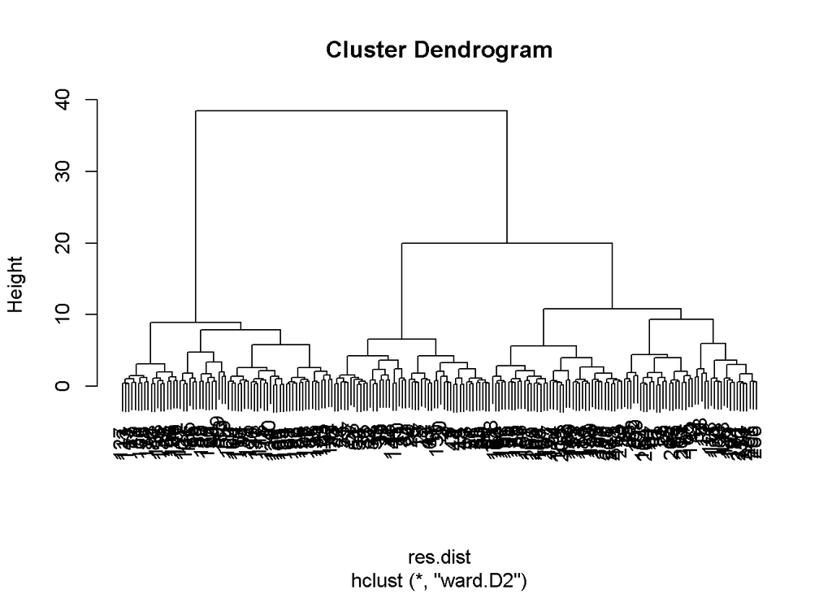

```r
plot(df_cluster)
```

```r
library(dplyr)
```

Zadanie 7. Ustaw przecięcie dendrogramu jako k=5, a następnie zaznacz na dendrogramie grupy.

```r
##rect.hclust(df_cluster, k=5, border="blue")
##Z jakiegos powodu mam problem z wyswietleniem tego, mimo ze w skrypcie wszystka dziala bez szwanku. Otrzymuje komunikat "plot.new has not been called yet"
```

Zadanie 8. Dodaj nr grupy jako nową zmienną do ramki danych

```r
groups <- cutree(df_cluster, k=5)
df <- cbind(df, groups)
df <- as.data.frame(df)
```

Zadanie 9. Utwórz tabele z podsumowaniem wyników: 1.Wartości średnie atrybutów w grupach 2.Liczebności utworzonych grup

```r
##podsumowanie
summary(subset(df, groups == 1))[4,1:7]
```

```
##               powierzchnia                      obwod
##       "Mean   :-0.01813  "       "Mean   :-0.01832  "
##                  zwiezlosc             dlugosc_ziarna
##       "Mean   : 0.38134  "       "Mean   :-0.07948  "
##           szerokosc_ziarna     wspolczynnik_asymetrii
##       "Mean   : 0.10115  "        "Mean   :-0.8393  "
## dlugosc_wyzlobienia_ziarna
##        "Mean   :-0.4032  "
```

```r
summary(subset(df, groups == 2))[4,1:7]
```

```
##               powierzchnia                      obwod
##        "Mean   :-0.6965  "        "Mean   :-0.7428  "
##                  zwiezlosc             dlugosc_ziarna
##       "Mean   : 0.01408  "       "Mean   :-0.78806  "
##           szerokosc_ziarna     wspolczynnik_asymetrii
##        "Mean   :-0.5575  "         "Mean   :1.4009  "
## dlugosc_wyzlobienia_ziarna
##       "Mean   :-0.72779  "
```

```r
summary(subset(df, groups == 3))[4,1:7]
```

```
##               powierzchnia                      obwod
##        "Mean   :-0.7992  "        "Mean   :-0.8551  "
##                  zwiezlosc             dlugosc_ziarna
##       "Mean   : 0.01504  "        "Mean   :-0.9024  "
##           szerokosc_ziarna     wspolczynnik_asymetrii
##        "Mean   :-0.6669  "        "Mean   :-0.5923  "
## dlugosc_wyzlobienia_ziarna
##        "Mean   :-1.0793  "
```

```r
summary(subset(df, groups == 4))[4,1:7]
```

```
##               powierzchnia                      obwod
##         "Mean   :1.2058  "         "Mean   :1.2091  "
##                  zwiezlosc             dlugosc_ziarna
##       "Mean   : 0.55552  "         "Mean   :1.1878  "
##           szerokosc_ziarna     wspolczynnik_asymetrii
##       "Mean   : 1.12311  "      "Mean   : 0.023626  "
## dlugosc_wyzlobienia_ziarna
##         "Mean   :1.2449  "
```

```r
summary(subset(df, groups == 5))[4,1:7]
```

```
##               powierzchnia                      obwod
##        "Mean   :-1.1509  "        "Mean   :-1.1032  "
##                  zwiezlosc             dlugosc_ziarna
##        "Mean   :-1.3649  "        "Mean   :-0.9484  "
##           szerokosc_ziarna     wspolczynnik_asymetrii
##        "Mean   :-1.2990  "        "Mean   : 0.5995  "
## dlugosc_wyzlobienia_ziarna
##        "Mean   :-0.5881  "
```

```r
##liczebnosci grup
nrow(filter(df, groups == 1))
```

```
## [1] 49
```

```r
nrow(filter(df, groups == 2))
```

```
## [1] 20
```

```r
nrow(filter(df, groups == 3))
```

```
## [1] 22
```

```r
nrow(filter(df, groups == 4))
```

```
## [1] 66
```

```r
nrow(filter(df, groups == 5))
```

```
## [1] 41
```

Zadanie 10. Narysuj wykres zależności powierzchni (oś x) od obwodu (oś y), zaznaczając kolorami utworzone grupy.

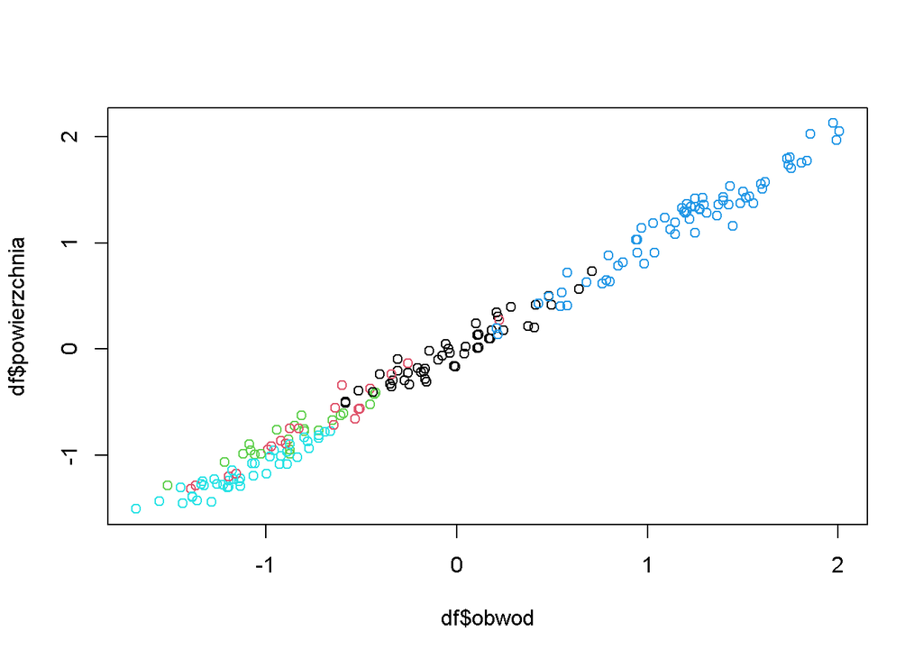

```r
plot(df$powierzchnia~df$obwod, df, col=groups)
```